# Lab 4

Steven Cabrera

2022-09-21

## Dataset #1

In this example, you have two continuous factors (e.g., elevation [meters] and degrees north latitude [degrees]), and one categorical factor with three groups (country). The dependent variable is lotus plant size (grams). In this system, there is no collinearity among your variables.

1. $Y = B_0 + B_1 X_1 + B_2 X_2 + B_3 X_3 + E \sim \text{N}(\mu, \sigma)$
   - X varibles:
     - $X_1$ = Latitude (continuous, degrees)
     - $X_2$ = Elevation (continuous, meters)
     - $X_3$ = Country (categorical, three groups = “India”, “Nepal”, “Tibet” ; reference = “India” in this case)
2. $B$ variables:
   - $B_0$: y-intercept
   - $B_1$: slope (estimate) of latitude
   - $B_2$: slope (estimate) of elevation
   - $B_3$: slope (estimate) of country
3. The significance of “Country” as a whole is $< 2.2e^{-16}$.
4. Example sentences:
   - For each 100 m increase in elevation, we observed a 0.162 (± 0.024; 95% C.I.) grams decrease in lotus plant size (p = < 2e-16).
   - For each 0.1 latitude increase, we observed a .1006 (± 0.017; 95% C.I.) grams decrease in lotus plant size (p = < 2e-16).
   - We found that Nepal had 3.59 (± 051; 95% C.I.) g less in lotus plant size than India (p = < 2e-16).
   - We found that Tibet had 1.73 (± 0.49; 95% C.I.) g less in lotus plant size than India (p = < 4.39e-10)
   - We found that Tibet had 1.86 (± 0.50; 95% C.I.) g more in lotus plant size than Nepal (p = 4.92e-11).

## Dataset #2

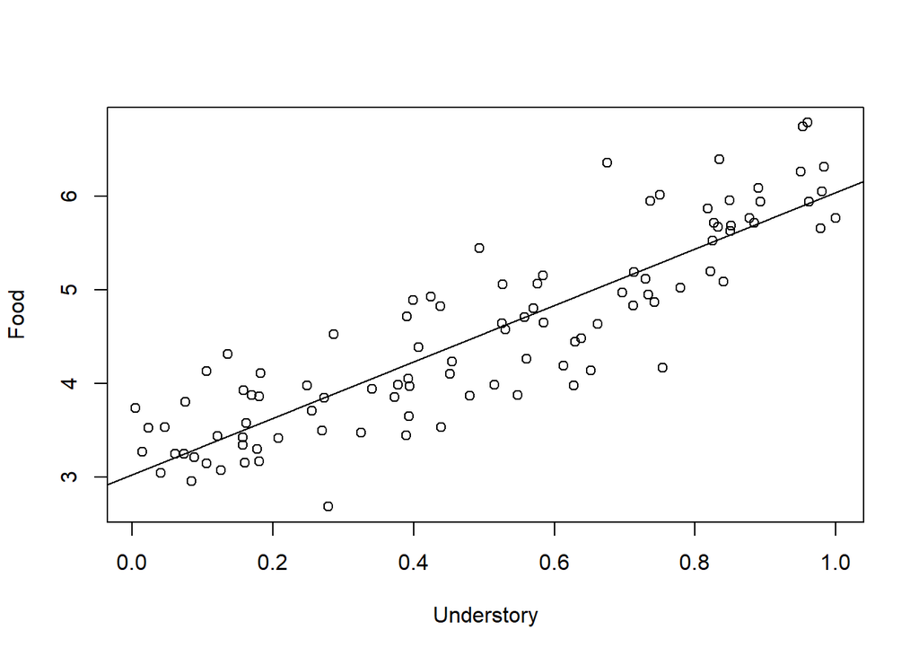

3. The $r^2$ between food and understory is 0.7746.

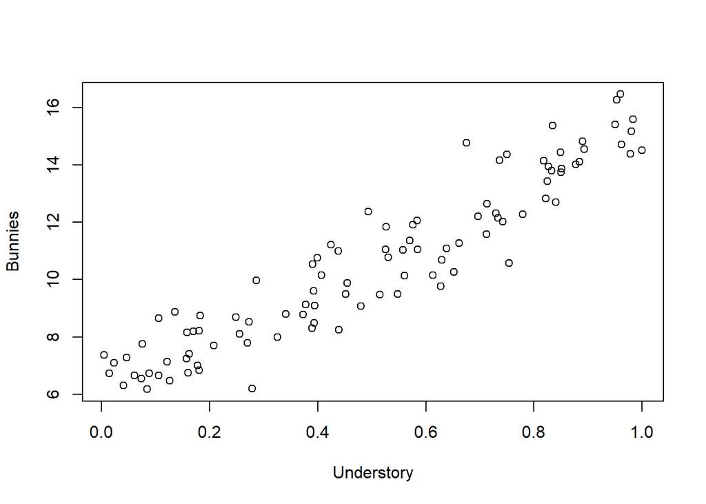

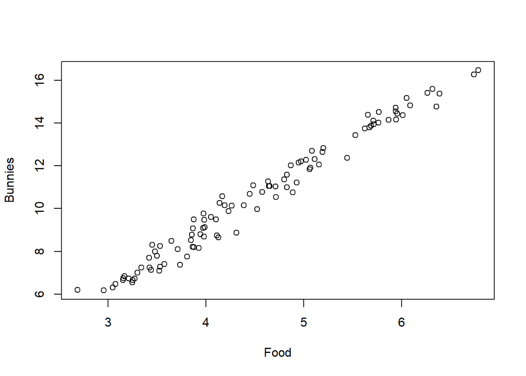

## Dataset #3

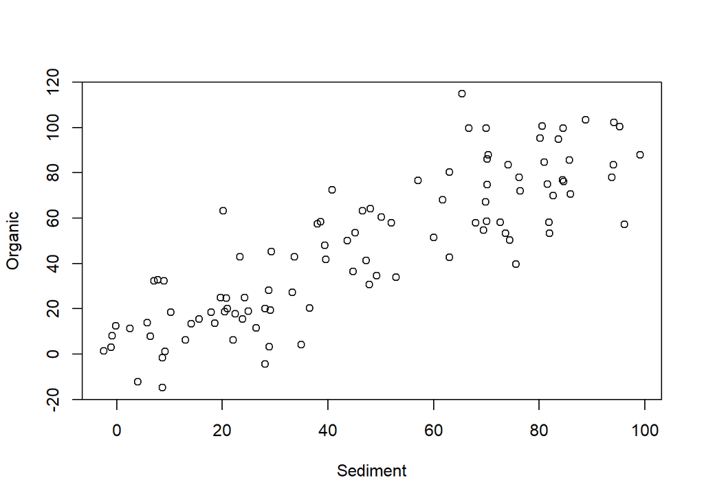

3. The $r^2$ between sediment and organic matter is 0.7289.

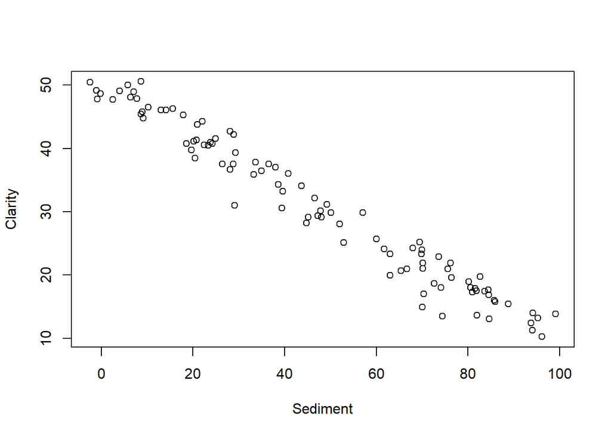

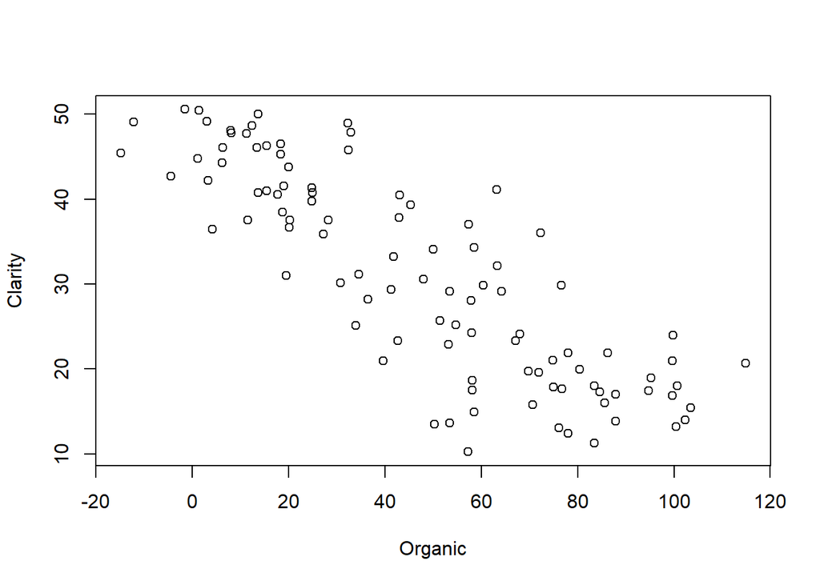

6. For each 1 gram/cm3 of sediment, we observed a 0.404 (± 0.016; 95% C.I.) cm decrease in clarity (p = < 2e-16, $r^2$ = 0.9635).
7. For each 1 gram/cm3 of organic matter, we observed a 0.32 (± 0.041; 95% C.I.) cm decrease in clarity (p = <2e-16, $r^2$ = 0.706).
8. For each 1 gram/cm3 of sediment, we observed a 0.4007 (± 0.0304; 95% C.I.) cm decrease in clarity (p = < 2e-16). For each 1 gram/cm3 of organic matter, we observed a 0.0034 (± 0.028; 95% C.I.) cm decrease in clarity (p = 0.81 **non-significant value**).
9. The VIF for sediment AND organic is 3.688.
10. The coefficient estimate of sediment (which is a better “index” of run-off) did not change much when modeled as a single regression compared to multiple regression with organic matter. In both bases, the coefficient is very close to truth (0.4 g/cm3). As the coefficient does not change, the collinear organic matter variable can be considered “redundant” and removed from the model, indicating no observable impact on run-off. I’ve learned that applying multiple models with the same data can be useful in exploratory analyses for eliminating redundant variables in collinear data.